# Regression is all you need

### Ejercicio: Howell

Los datos contenidos en “howell1.csv” son datos censales parciales del área !Kung San compilados a partir de entrevistas realizadas a finales de la década de 1960. Crea un modelo para predecir el peso de los individuos a partir de la altura y el sexo. Evalúa la bondad del modelo.

```r
# ??
```

### Ejemplo: dummy variables y contrastes

El dataset `iris` (puedes obtenerlo con `data(iris)`) contiene medidas del sépalo y pétalo de varias especies de iris. Construye un modelo lineal para predecir la longitud del sépalo únicamente en función de la especie. Interpreta los coeficientes de la regresión.

```r
data(iris)
iris_model = lm(Sepal.Length ~ Species, iris)
print(summary(iris_model))
```

```
##
## Call:
## lm(formula = Sepal.Length ~ Species, data = iris)
##
## Residuals:
##     Min      1Q  Median      3Q     Max
## -1.6880 -0.3285 -0.0060  0.3120  1.3120
##
## Coefficients:
##                   Estimate Std. Error t value Pr(>|t|)
## (Intercept)         5.0060     0.0728  68.762  < 2e-16 ***
## Speciesversicolor   0.9300     0.1030   9.033 8.77e-16 ***
## Speciesvirginica    1.5820     0.1030  15.366  < 2e-16 ***
## ---
## Signif. codes:  0 '***' 0.001 '**' 0.01 '*' 0.05 '.' 0.1 ' ' 1
##
## Residual standard error: 0.5148 on 147 degrees of freedom
## Multiple R-squared:  0.6187, Adjusted R-squared:  0.6135
## F-statistic: 119.3 on 2 and 147 DF,  p-value: < 2.2e-16
```

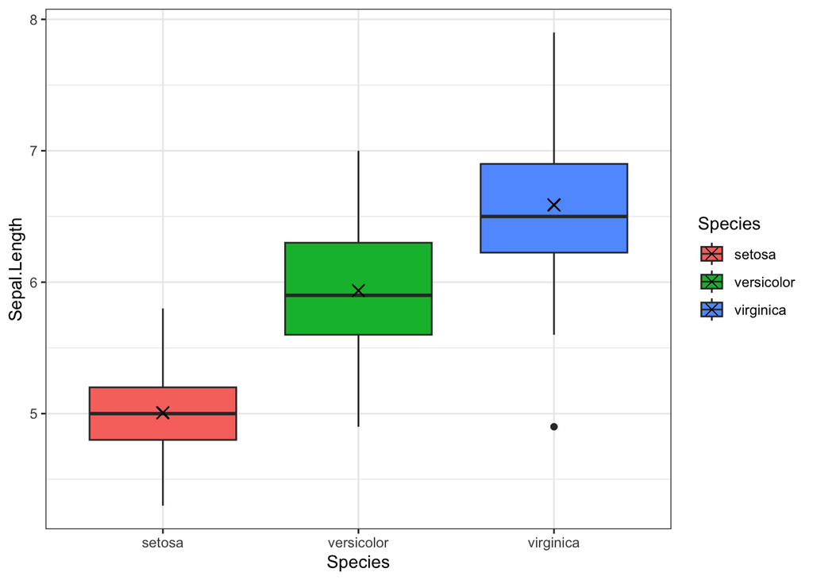

```r
iris_preds = bind_cols(iris, fit = predict(iris_model))
ggplot(iris_preds, aes(x=Species, fill = Species)) +
  geom_boxplot(aes(y=Sepal.Length)) +
  geom_point(aes(y = fit), shape=4, size=3)
```

Al interpretar los coeficientes de la regresión, observamos que `lm` ha tomado como referencia la especie `setosa`. Esto se puede observar usando `contrasts`.

```r
contrasts(iris$Species)
```

```
##            versicolor virginica
## setosa              0         0
## versicolor          1         0
## virginica           0         1
```

Es decir el modelo es
$$sepal =
\text{mean-setosa-sepal} + 0.93 * versicolor + 1.58 *
virginica.$$

Sin embargo, podríamos reescribir el modelo de otra forma de forma que los coeficientes tengan otro significado. Un ejemplo sencillo sería:
$$sepal = \text{mean-versicolor-sepal} +
\alpha_1 * setosa + \alpha_2 * virginica.$$

En este caso, simplimente estamos variando la especie de referencia. De hecho, `contrasts` se puede modificar para usar como referencia otro nivel del factor:

### Ejemplo: contrastes

```r
iris$Species = relevel(iris$Species, "versicolor")
contrasts(iris$Species)
```

```
##            setosa virginica
## versicolor      0         0
## setosa          1         0
## virginica       0         1
```

```r
iris_model_2 = lm(Sepal.Length ~ Species, iris)
print(summary(iris_model_2))
```

```
##
## Call:
## lm(formula = Sepal.Length ~ Species, data = iris)
##
## Residuals:
##     Min      1Q  Median      3Q     Max
## -1.6880 -0.3285 -0.0060  0.3120  1.3120
##
## Coefficients:
##                  Estimate Std. Error t value Pr(>|t|)
## (Intercept)        5.9360     0.0728  81.536  < 2e-16 ***
## Speciessetosa     -0.9300     0.1030  -9.033 8.77e-16 ***
## Speciesvirginica   0.6520     0.1030   6.333 2.77e-09 ***
## ---
## Signif. codes:  0 '***' 0.001 '**' 0.01 '*' 0.05 '.' 0.1 ' ' 1
##
## Residual standard error: 0.5148 on 147 degrees of freedom
## Multiple R-squared:  0.6187, Adjusted R-squared:  0.6135
## F-statistic: 119.3 on 2 and 147 DF,  p-value: < 2.2e-16
```

Lo interesante es que podemos **ajustar los contrastes de forma que respondan a nuestras preguntas científicas**. En general, estos contrastes deben ser **ortogonales**.

### Ejemplo: contrastes ortogonales

Imagínemonos el siguiente universo paralelo. En este universo paralelo solo existe la especie setosa. Una empresa de ingeniería genética te contrata para crear nuevas especies con un sépalo más grande. Desarrollas un método conocido como “Método V”, que tiene dos variantes “V-I” y “V-II”. Los experimentos con estas variantes dan lugar a dos nuevas especies que llamas versicolor (V-I) y virginica (V-II). Te planteas dos preguntas científicas:

1. ¿Es el método V capaz de crear especies con el sépalo más grande?
2. ¿Existe alguna diferencia entre V-I y V-II?

```r
suppressPackageStartupMessages(
  source("utils.R")   # cargamos get_contrasts_coding
)
# Cambiamos otra vez la especie referencia (no es necesario, pero para tener
# a las vs juntas)
iris$Species = relevel(iris$Species, "setosa")
levels(iris$Species)
```

```
## [1] "setosa"     "versicolor" "virginica"
```

```r
contrasts(iris$Species)
```

```
##            versicolor virginica
## setosa              0         0
## versicolor          1         0
## virginica           0         1
```

```r
my_contrasts = rbind(
  "V - setosa" = c(-1, 0.5, 0.5),
  "I - II" = c(0, 1, -1)
)
my_coding = get_contrasts_coding(my_contrasts)
contrasts(iris$Species) = my_coding
contrasts(iris$Species)
```

```
##            V - setosa I - II
## setosa     -0.6666667    0.0
## versicolor  0.3333333    0.5
## virginica   0.3333333   -0.5
```

```r
v_model = lm(Sepal.Length ~ Species, iris)
summary(v_model)
```

```
##
## Call:
## lm(formula = Sepal.Length ~ Species, data = iris)
##
## Residuals:
##     Min      1Q  Median      3Q     Max
## -1.6880 -0.3285 -0.0060  0.3120  1.3120
##
## Coefficients:
##                   Estimate Std. Error t value Pr(>|t|)
## (Intercept)        5.84333    0.04203 139.020  < 2e-16 ***
## SpeciesV - setosa  1.25600    0.08916  14.086  < 2e-16 ***
## SpeciesI - II     -0.65200    0.10296  -6.333 2.77e-09 ***
## ---
## Signif. codes:  0 '***' 0.001 '**' 0.01 '*' 0.05 '.' 0.1 ' ' 1
##
## Residual standard error: 0.5148 on 147 degrees of freedom
## Multiple R-squared:  0.6187, Adjusted R-squared:  0.6135
## F-statistic: 119.3 on 2 and 147 DF,  p-value: < 2.2e-16
```

```r
confint(v_model)
```

```
##                        2.5 %     97.5 %
## (Intercept)        5.7602675  5.9263991
## SpeciesV - setosa  1.0797908  1.4322092
## SpeciesI - II     -0.8554688 -0.4485312
```

El método V parace producir sépalos más grandes. Por otra parte, V-II es mejor que V-I.

LLegados a este punto, ¡ya hemos cubierto el 90% de los contenidos habituales de un curso de estadística habitual! Aunque parezca mentira, ya hemos hecho análisis tan complejos como

- Análisis de la varianza (anova): por ejemplo, en el problema del método V,
- Análisis de la covarianza (ancova): con el dataset `antrop.csv` o `howell`,
- …

Desde una perspectiva moderna, **todos los análisis clásicos (T-test, anova, ancova) pueden considerarse como simples modelos de regresión**. Esto demuestra el poder unificador de esta perspectiva. En las siguientes secciones revisaremos sin embargo estos modelos clásicos para afianzar la conexión con los modelos de regresión.

### Ejercicio: ¿Qué influye en los salarios?

Añade la variable sexo al modelo de los salarios. ¿Cuál es la diferencia en ganancias para hombres y mujeres de la misma altura?

```r
# ???
# Resultado esperado: a igualdad de condiciones, los hombres ganan un 30.4% más que las mujeres
```

Añade la variable educación al modelo de los salarios. Modifica los contrastes para responder a las siguientes preguntas:

1. ¿Merece la pena estudiar “high school” o “universidad” o basta con quedarse en “elementary” (en términos de salario)?
2. ¿Merece la pena estudiar “universidad” comparado con “high school”?

```r
# ??????
# Resultado esperado: sí merece la pena, con incrementos en las ganancias del 83.58% y 33.68%, respectivamente.
```